# Visualisation avec ggplot

# 3 variables numériques (dont une >0)

# + catégories

## Scatter plot + couleur + taille

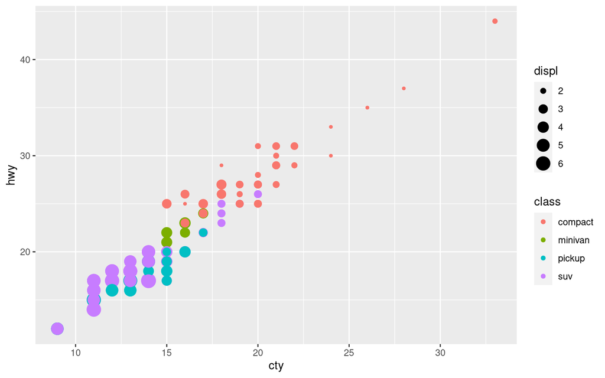

```r
ggplot(mpg_su)+geom_point(aes(x=cty,y=hwy,color=class,size=displ))
```

## Scatter plot + couleur + taille ! echelles

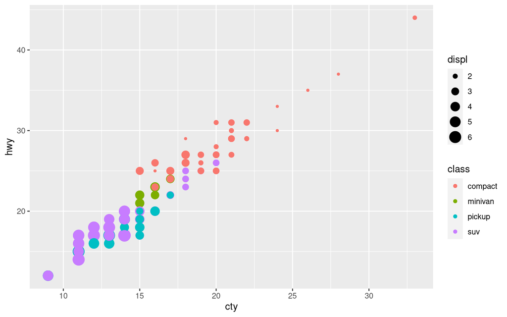

```r
ggplot(mpg_su)+geom_point(aes(x=cty,y=hwy,color=class,size=displ))
```

# Taille des cercles : échelle aire ou rayon ?

#### Rayon

#### Aire

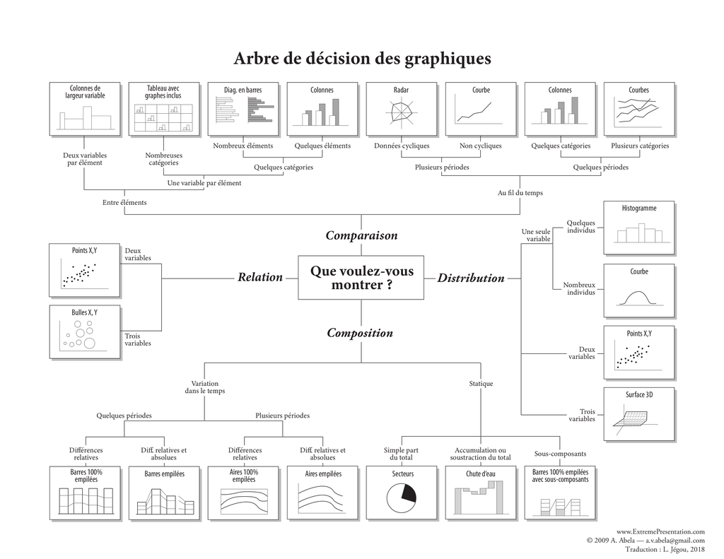

# Principes :

# Eviter de mentir, Lie Factor

$$\textrm{Lie factor} = \frac{\textrm{visual effect size}}{\textrm{data effect size}}$$

# Lie factor :

$$\textrm{data effect size} = \frac{27.5 - 18}{18} \times 100 = 53 \%$$

#### Edward Tufte, The Visual Display of Quantitative Information, Cheshire, CT, Graphics Press, 2001, 2e éd. (1re éd. 1983)

# Lie factor :

$$\textrm{visual effect size} = \frac{5.3 -0.6}{0.6} \times 100 = 783 \%$$

#### Edward Tufte, The Visual Display of Quantitative Information, Cheshire, CT, Graphics Press, 2001, 2e éd. (1re éd. 1983)

# Lie factor :

$$\textrm{Lie factor} = \frac{783}{53} = 14.8$$

#### Edward Tufte, The Visual Display of Quantitative Information, Cheshire, CT, Graphics Press, 2001, 2e éd. (1re éd. 1983)

# Lie factor : 9.4

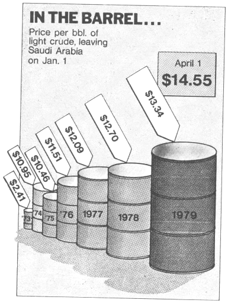

#### Edward Tufte, The Visual Display of Quantitative Information, Cheshire, CT, Graphics Press, 2001, 2e éd. (1re éd. 1983)

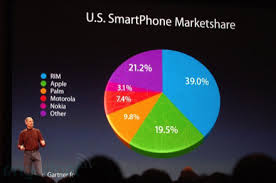

Sachant que l’aire de la tranche “apple”" (en vert) est proportionelle à $2.22\,cm^2$ et celle correspondant à rim (en bleue) est proportionelle à $2.96\,cm^2$ calculer le lying factor ?

## Perception

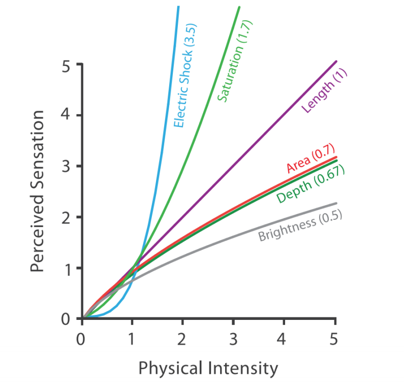

$$S = I^p$$

# Principes :

# Augmenter la densité de données

$$\textrm{graph data density} =$$
$$\frac{\textrm{number of entries in data matrix}}{\textrm{area of data display}}$$

# Data density :

#### Eviter les graphique à faible densité

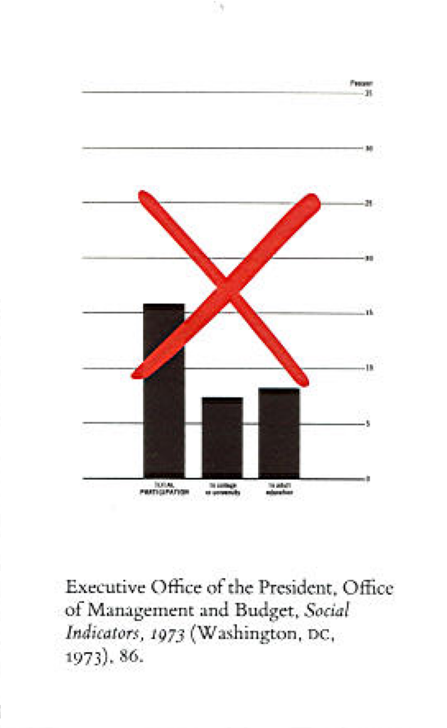

#### Edward Tufte, The Visual Display of Quantitative Information, Cheshire, CT, Graphics Press, 2001, 2e éd. (1re éd. 1983)

# Data density :

#### Meilleure densité de donnée

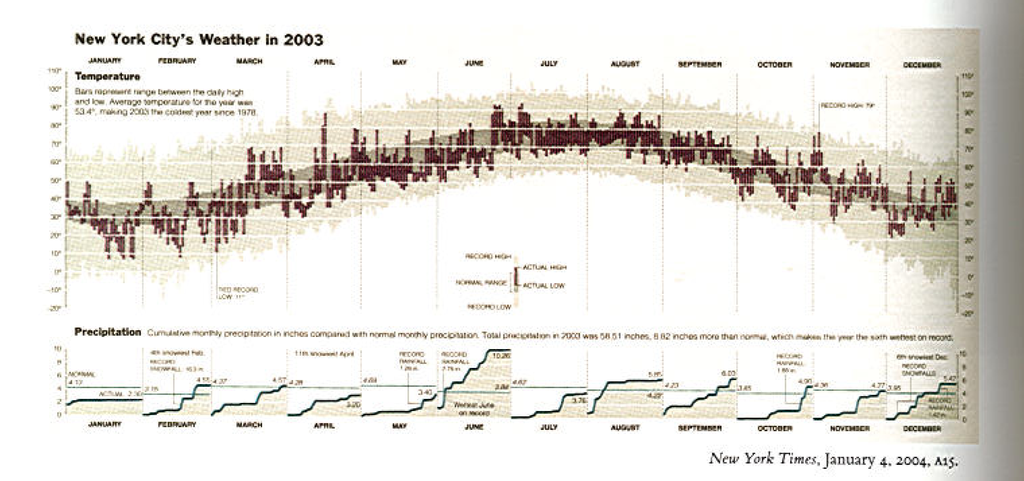

#### Edward Tufte, The Visual Display of Quantitative Information, Cheshire, CT, Graphics Press, 2001, 2e éd. (1re éd. 1983)

##Bonnes pratiques :

- éviter de mentir !
- faire des graphiques riches
- avec des encodages adaptés
- de bonnes échelles, (!couleurs, !aires)
- des axes labelisés
- ordre des facteurs
- aspect ratio
- format d’enregistrements pdf, svg // png,jpg

## ggplot

# gg = grammar of graphics

- “The Grammar of Graphics” (Wilkinson, Annand and Grossman, 2005)
- grammaire → même type de description pour des graphique différents

## ggplot

#### Composants de la grammaires :

data and aesthetic mappings,  
ex : f(data) → x position, y position, size, shape, color

geometric objects,  
ex : points, lines, bars, texts

scales,  
ex : f([0, 100]) → [0, 5] px

facet specification,  
ex : segmentation des données suivant un ou plusieurs facteurs

statistical transformations,  
ex : moyenne, comptage, régression

the coordinate system.

## ggplot

#### Création d’un graphique :

ajout successif de layers (calques)

définissant un mapping des données vers leurs représentation

(+ optionel) définition de transformations statistique

(+ optionel) définition des échelles

(+ optionel) gestion du thème des titre …

#### ! Données toujours sous forme de data.frame bien formatées

## ggplot, géométries

#### Création d’un graphique :

ajout successif de layers (calques)

```r
+geom_line()
```

définissant un mapping des données vers leurs représentation

```r
aes(x=a,y=b,...)
```

#### Exemple

```r
ggplot(mpg)+
  geom_point(aes(x=cty,y=hwy,color=manufacturer,shape=factor(cyl)))
ggplot(mpg,aes(x=cty,y=hwy,color=manufacturer,shape=factor(cyl)))+
  geom_jitter()
```

## ggplot

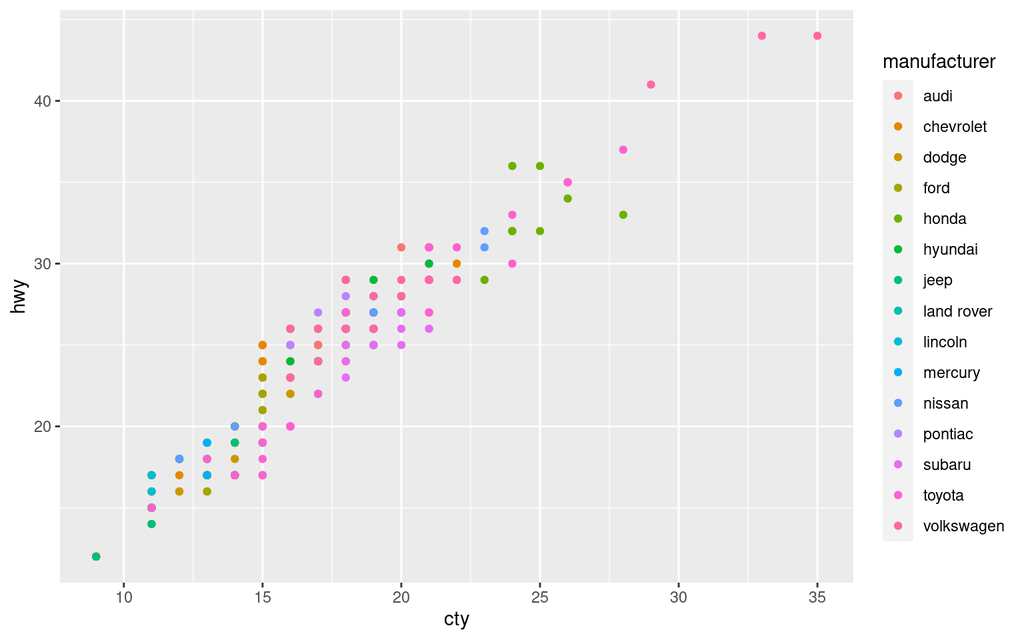

```r
ggplot(mpg,aes(x=cty,y=hwy,color=manufacturer))+geom_point()
```

## ggplot

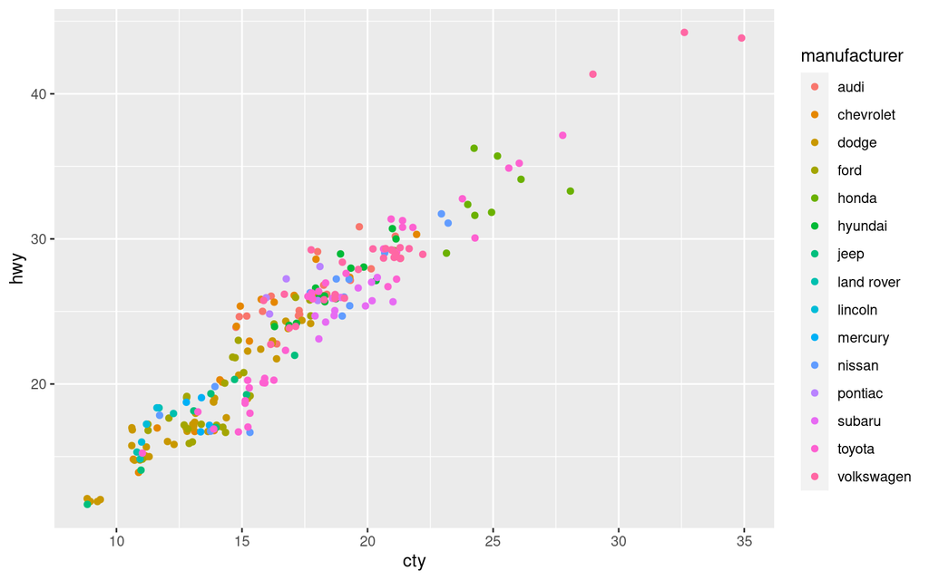

```r
ggplot(mpg,aes(x=cty,y=hwy,color=manufacturer))+geom_jitter()
```

## ggplot

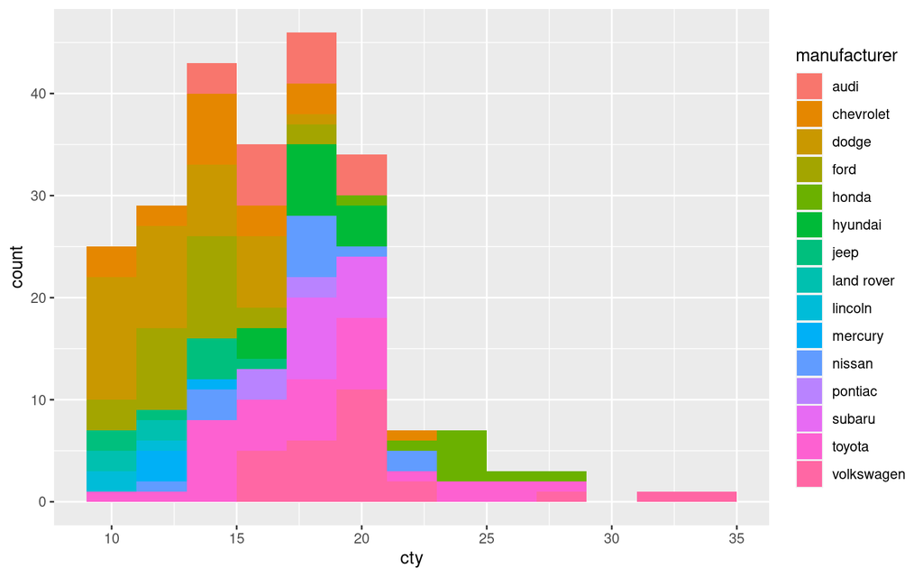

```r
ggplot(mpg,aes(x=cty,fill=manufacturer))+geom_histogram(binwidth=2)
```

## ggplot

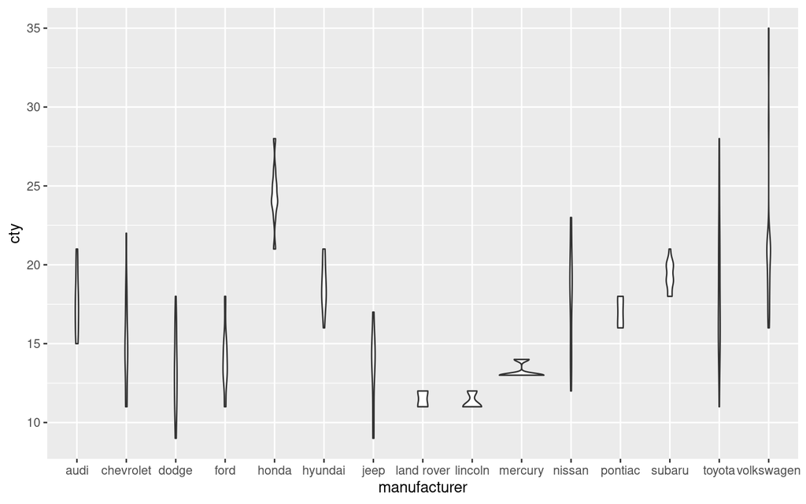

```r
ggplot(mpg,aes(y=cty,x=manufacturer))+geom_violin()
```

##ggplot, échelles

#### Création d’un graphique :

ajout successif de layers (calques)

```r
+geom_line()
```

définissant un mapping des données vers leurs représentation

```r
aes(x=a,y=b,...)
```

en fixant les échelles

```r
scale_fill_brewer(palette=3,type="qual")
scale_x_continuous(limits=c(0,45),breaks=seq(0,45,2))
```

## ggplot, échelles

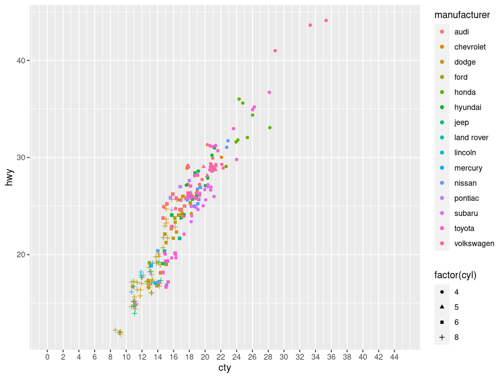

```r
ggplot(mpg,aes(x=cty,y=hwy,color=manufacturer,shape=factor(cyl)))+
  geom_jitter()+
  scale_x_continuous(limits=c(0,45),breaks=seq(0,45,2))
```

# Echelles de couleurs

## Echelle de couleurs

# http://colorbrewer2.org/

## ggplot, facettes

#### Création d’un graphique :

ajout successif de layers (calques)

```r
+geom_line()
```

définissant un mapping des données vers leurs représentation

```r
aes(x=a,y=b,...)
```

en fixant les échelles

```r
scale_fill_brewer(palette=3,type="qual")
scale_x_continuous(limits=c(0,45),breaks=seq(0,45,2))
```

en créant des facettes

```r
facet_grid(. ~ cyl)
```

## ggplot, facettes

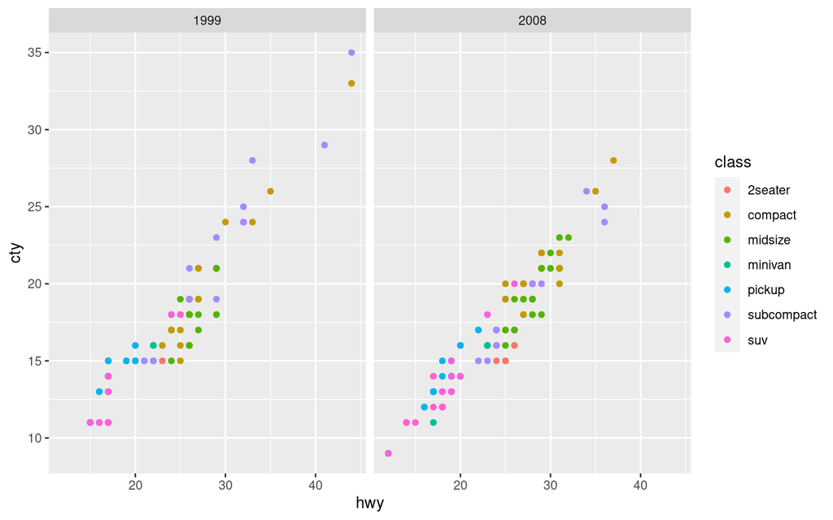

```r
ggplot(data=mpg,aes(x=hwy,y=cty,color=class))+
  geom_point()+
  facet_wrap(~year)
```

## ggplot, stats

#### Création d’un graphique :

ajout successif de layers (calques)

```r
+geom_line()
```

définissant un mapping des données vers leurs représentation

```r
aes(x=a,y=b,...)
```

en fixant les échelles

```r
scale_fill_brewer(palette=3,type="qual")
scale_x_continuous(limits=c(0,45),breaks=seq(0,45,2))
```

en ajoutant des stats

```r
stat_density2d()
```

## ggplot

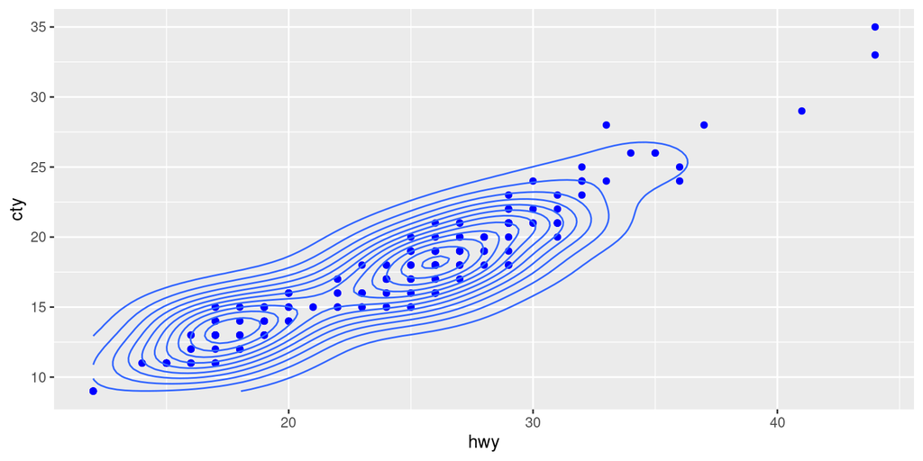

```r
ggplot(mpg,aes(y=cty,x=hwy))+
  geom_point(color="blue")+stat_density2d()
```

## ggplot

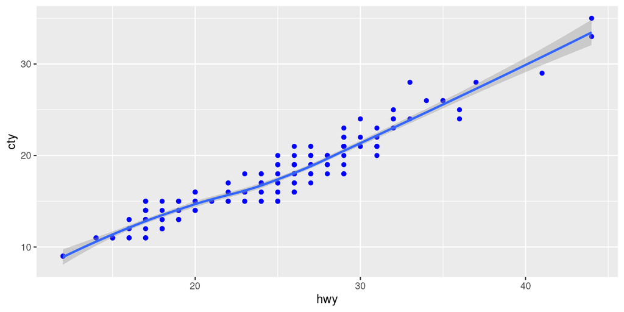

```r
ggplot(mpg,aes(y=cty,x=hwy))+
  geom_point(color="blue")+stat_smooth()
```